# core-practices-over-time

Anwesha Guha

2024-04-14

## Notes for April 19 DAC Meeting

For this analysis, I used the 2024 core practices data and the `time_` variable to piece together answers to the following questions below. I didn’t see `core_` practices in the longitudinal data, but I would be curious to see how the `time_` variable, if self-reported, aligns (or not) to the actual reported use each year.

Hopefully the tables and graphs below are self-explanatory, but any decision points are still noted below.

## Core Practices

### How frequently are core practices selected in 2024?

This is a simple count of times each core practice is selected this year. The top two byfar are **pbl** (n = 65) and **competency_education** (n = 58). These are selected at least 22 times more frequently than any other core practice on the list.

```r
core_prac <- tags %>%
  select(starts_with("core_")) %>%
  summarise(across(where(is.numeric), ~ sum(.x, na.rm = TRUE))) %>%
  pivot_longer(everything(),
               names_to = "core_practice (N = 73)",
               values_to = "times_selected") %>%
  arrange(-times_selected)

# could create into pct, but should specify denom: ex., mutate(Pct = paste0(round(N/251*100, 2), "%"))

datatable(core_prac)
```

|  | core_practice (N = 73) | times_selected |
| --- | --- | --- |
| 1 | core_pbl | 65 |
| 2 | core_competency_education | 58 |
| 3 | core_inclusion | 36 |
| 4 | core_accommodations | 35 |
| 5 | core_sel_integrated | 34 |
| 6 | core_community_partnerships | 32 |
| 7 | core_career_prep | 31 |
| 8 | core_interdisciplinary | 30 |
| 9 | core_mtss_academics | 29 |
| 10 | core_restorative | 29 |

[output cut: 63 more lines]

### How long have schools been implementing each core practice?

It looks like **pbl** and **competency_education** as the most popular core practices are being implemented 5+ years. For the 3-4 year mark, **mtss_academics** also makes an appearance.

```r
implementation_time <- tags %>%
  select(starts_with("time_")) %>%
  pivot_longer(everything(),
               names_to = "practice",
               values_to = "N") %>%
  mutate(`Not sure` = case_when(N == "Not sure" ~ 1,
                                TRUE ~ 0),
         `Less than a year` = case_when(N == "Less than a year" ~ 1,
                                 TRUE ~ 0),
         `1-2 years` = case_when(N == "1-2 years" ~ 1,
                                 TRUE ~ 0),
         `3-4 years` = case_when(N == "3-4 years" ~ 1,
                                 TRUE ~ 0),
         `5+ years` = case_when(N == "5+ years" ~ 1,
                                TRUE ~ 0),
         practice = sub("time_", "", practice)) %>%
  select(!N) %>%
  group_by(practice) %>%
  summarise(across(where(is.numeric), ~ sum(.x, na.rm = TRUE)))


datatable(implementation_time)
```

|  | practice | Not sure | Less than a year | 1-2 years | 3-4 years | 5+ years |
| --- | --- | --- | --- | --- | --- | --- |
| 1 | a_la_carte | 0 | 0 | 0 | 0 | 3 |
| 2 | accommodations | 0 | 1 | 2 | 5 | 27 |
| 3 | adult_wellness | 0 | 1 | 0 | 0 | 3 |
| 4 | advancement_mastery | 0 | 0 | 0 | 2 | 5 |
| 5 | advisories | 0 | 0 | 0 | 1 | 16 |
| 6 | anti_racist | 0 | 0 | 2 | 1 | 4 |
| 7 | assessments_agency | 0 | 1 | 0 | 0 | 1 |
| 8 | assessments_bilingual | 0 | 0 | 0 | 0 | 1 |
| 9 | assessments_career | 0 | 0 | 1 | 0 | 2 |
| 10 | assessments_deeper | 0 | 1 | 4 | 2 | 14 |

[output cut: 63 more lines]

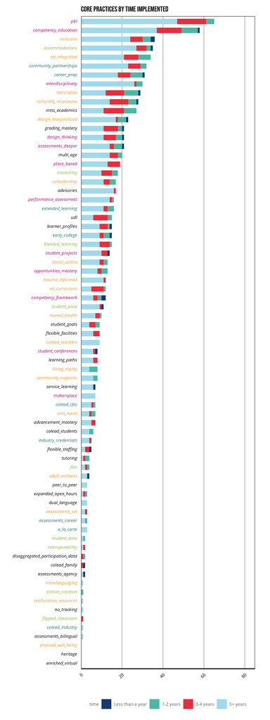

```r
# Plot dat setup
implementation_time_plot <- implementation_time %>%
  pivot_longer(cols = c(`Less than a year`, `1-2 years`, `3-4 years`, `5+ years`),
               names_to = "time",
               values_to = "N") %>%
  mutate(time = factor(time, levels = c(
    "Less than a year",
    "1-2 years",
    "3-4 years",
    "5+ years"
  )))

# Practice axes setup
cluster_colors <- unique(old_clusters$cluster) %>%
  setNames(object = c(transcend_cols2[c(1, 2, 4, 5)], "#000000"))

clusters <- old_clusters %>%
  mutate(practice = sub("practices_", "", var)) %>%
  select(-var)

implementation_with_color <- left_join(implementation_time_plot, clusters, by = "practice") %>%
  mutate(
    color = cluster_colors[cluster],
    practice = fct_inorder(glue("<i style='color:{color}'>{practice}</i>"))
  )

# Plot (referenced Gregor's code)
ggplot(implementation_with_color, aes(reorder(practice, N), N, fill = time)) +
  geom_col() +
  scale_fill_manual(values = transcend_cols) +
  scale_y_continuous(limits=c(0, 85), expand = c(0,0)) +
  labs(title = "Core Practices by Time Implemented",
       x = "",
       y = "") +
  scale_x_discrete(labels = label_tags()) +
  theme(legend.position = "bottom",
        legend.direction = "horizontal",
        text = element_text(size = 7),
        axis.text.x = element_text(angle = 45, hjust = 1)) +
  coord_flip() +
  theme(
    panel.grid.major.y = element_blank(),
    legend.position = "bottom",
    axis.text.y = element_markdown()
  )
```

### Which core practices have “legacy” or “established” schools chosen?

This question arises first from selecting the schools that have participated in the survey for at least 4 years. For these, **pbl** and **competency_education** still take the lead.

```r
repeaters_4 <- long_dat %>%
  select(school_id, year) %>%
  unique() %>%
  mutate(rate = 1) %>%
  pivot_wider(names_from = "year",
              values_from = "rate") %>%
  rowwise() %>%
  mutate(participate = sum(`2019`, `2021`, `2022`, `2023`, `2024`, na.rm = TRUE)) %>%
  filter(participate > 3) %>%
  pull(school_id)
```

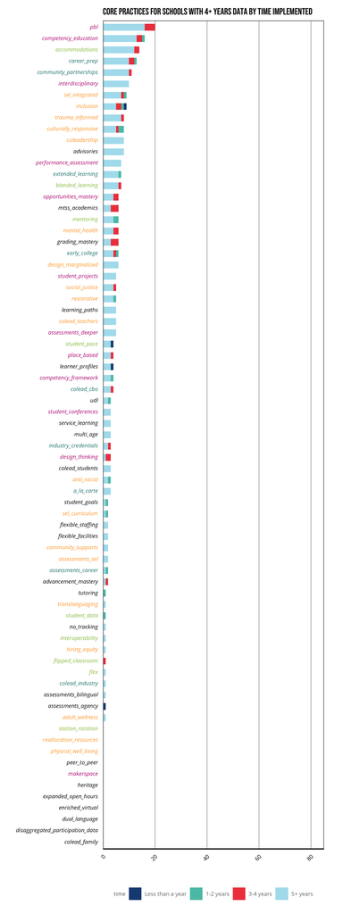

```r
implementation_time_repeaters <- tags %>%
  filter(school_id %in% repeaters_4) %>%
  select(starts_with("time_")) %>%
  pivot_longer(everything(),
               names_to = "practice",
               values_to = "N") %>%
  mutate(`Not sure` = case_when(N == "Not sure" ~ 1,
                                TRUE ~ 0),
         `Less than a year` = case_when(N == "Less than a year" ~ 1,
                                 TRUE ~ 0),
         `1-2 years` = case_when(N == "1-2 years" ~ 1,
                                 TRUE ~ 0),
         `3-4 years` = case_when(N == "3-4 years" ~ 1,
                                 TRUE ~ 0),
         `5+ years` = case_when(N == "5+ years" ~ 1,
                                TRUE ~ 0),
         practice = sub("time_", "", practice)) %>%
  select(!N) %>%
  group_by(practice) %>%
  summarise(across(where(is.numeric), ~ sum(.x, na.rm = TRUE))) %>%
  pivot_longer(cols = c(`Less than a year`, `1-2 years`, `3-4 years`, `5+ years`),
               names_to = "time",
               values_to = "N") %>%
  mutate(time = factor(time, levels = c(
    "Less than a year",
    "1-2 years",
    "3-4 years",
    "5+ years"
  )))

implementation_repeaters_with_color <- left_join(implementation_time_repeaters, clusters, by = "practice") %>%
  mutate(
    color = cluster_colors[cluster],
    practice = fct_inorder(glue("<i style='color:{color}'>{practice}</i>"))
  )

# Plot (referenced Gregor's code)
ggplot(implementation_repeaters_with_color, aes(reorder(practice, N), N, fill = time)) +
  geom_col() +
  scale_fill_manual(values = transcend_cols) +
  scale_y_continuous(limits=c(0, 85), expand = c(0,0)) +
  labs(title = "Core Practices for Schools with 4+ years data by Time Implemented",
       x = "",
       y = "") +
  scale_x_discrete(labels = label_tags()) +
  theme(legend.position = "bottom",
        legend.direction = "horizontal",
        text = element_text(size = 7),
        axis.text.x = element_text(angle = 45, hjust = 1)) +
  coord_flip() +
  theme(
    panel.grid.major.y = element_blank(),
    legend.position = "bottom",
    axis.text.y = element_markdown()
  )
```